# Neiman_ProjectFirstUpdate

### UW Data Science: Machine Learning Techniques

##### May 3, 2018

#### 1. Abstract

As big metropolitan areas continue to grow there is a need to reduce vehicle congestion for convenience and safety reasons but also as a means of cutting back on emissions and meeting cliamte change adaptation goals. An increasingly popular solution to this problem has been the deployment of bikeshares in cities across the country. This project will look specifically at bikeshare data from San Francisco along with contemporary weather data. Using machine learning methods this project aims to see how weather and time factors (hour of day, day of week, etc.) trip duration. This will help city commuters who want to bike commute for economic or environmental plan their trips better.

```python
import pandas as pd
import numpy as np
import matplotlib.pyplot as plt
from IPython.display import Image
from sklearn.preprocessing import scale
from sklearn.ensemble import RandomForestRegressor
from sklearn.model_selection import train_test_split
from sklearn.model_selection import KFold
from sklearn import svm
import matplotlib.style as style
style.use('fivethirtyeight')

%matplotlib inline
```

#### 2. Data Loading and Preprocessing

Here I will load in both weather and bikeshare datasets. Both were found on Kaggle at the following links:

- Weather: https://www.kaggle.com/selfishgene/historical-hourly-weather-data
- Bikeshare: https://www.kaggle.com/benhamner/sf-bay-area-bike-share/data

```python
trips = pd.read_csv('./Data/trip.csv')
stns = pd.read_csv('./Data/station.csv')
#status = pd.read_csv('./Data/status.csv')
temp = pd.read_csv('./Data/temperature.csv')
hum = pd.read_csv('./Data/humidity.csv')
desc = pd.read_csv('./Data/weather_description.csv')
```

```python
# Select only SF temperatures, convert from Kelvin to Fahrenheit
sf_temp = temp[['datetime','San Francisco']].iloc[1:]
sf_temp['datetime'] = pd.to_datetime(sf_temp.datetime,format = '%Y-%m-%d %H:%M:%S')
sf_temp['San Francisco'] = round((sf_temp['San Francisco']-273.15)*1.8+32,2)
sf_temp.columns = ['datetime','temperature']
```

```python
# Repeat process for humidity readings
sf_hum = hum[['datetime','San Francisco']].iloc[1:]
sf_hum.columns = ['datetime','humidity']
sf_hum['datetime'] = pd.to_datetime(sf_hum.datetime,format = '%Y-%m-%d %H:%M:%S')
```

```python
# Preprocess weather descriptions
sf_desc = desc[['datetime','San Francisco']].iloc[1:]
sf_desc['datetime'] = pd.to_datetime(sf_desc.datetime,format = '%Y-%m-%d %H:%M:%S')
sf_desc.columns = ['datetime','description']
# Convert to dummy variables
sf_desc = pd.get_dummies(sf_desc,columns=['description'])
```

```python
# Merge weather data on timestamp
sf_weather = pd.merge(sf_temp,sf_hum, on = 'datetime')
sf_weather = pd.merge(sf_weather,sf_desc, on = 'datetime')
sf_weather.head()
```

|  | datetime | temperature | humidity | description_broken clouds | description_drizzle | description_few clouds | description_fog | description_haze | description_heavy intensity drizzle | description_heavy intensity rain | ... | description_scattered clouds | description_shower rain | description_sky is clear | description_smoke | description_squalls | description_thunderstorm | description_thunderstorm with heavy rain | description_thunderstorm with light rain | description_thunderstorm with rain | description_very heavy rain |
| --- | --- | --- | --- | --- | --- | --- | --- | --- | --- | --- | --- | --- | --- | --- | --- | --- | --- | --- | --- | --- | --- |
| 0 | 2012-10-01 13:00:00 | 61.39 | 88.0 | 0 | 0 | 0 | 0 | 0 | 0 | 0 | ... | 0 | 0 | 0 | 0 | 0 | 0 | 0 | 0 | 0 | 0 |
| 1 | 2012-10-01 14:00:00 | 61.38 | 87.0 | 0 | 0 | 0 | 0 | 0 | 0 | 0 | ... | 0 | 0 | 1 | 0 | 0 | 0 | 0 | 0 | 0 | 0 |
| 2 | 2012-10-01 15:00:00 | 61.36 | 86.0 | 0 | 0 | 0 | 0 | 0 | 0 | 0 | ... | 0 | 0 | 1 | 0 | 0 | 0 | 0 | 0 | 0 | 0 |
| 3 | 2012-10-01 16:00:00 | 61.33 | 85.0 | 0 | 0 | 0 | 0 | 0 | 0 | 0 | ... | 0 | 0 | 1 | 0 | 0 | 0 | 0 | 0 | 0 | 0 |
| 4 | 2012-10-01 17:00:00 | 61.31 | 84.0 | 0 | 0 | 0 | 0 | 0 | 0 | 0 | ... | 0 | 0 | 1 | 0 | 0 | 0 | 0 | 0 | 0 | 0 |

5 rows × 31 columns

```python
# Format ride start/end times as dates
trips['start_date'] = pd.to_datetime(trips.start_date,format = '%m/%d/%Y %H:%M')
trips['end_date'] = pd.to_datetime(trips.end_date,format = '%m/%d/%Y %H:%M')
# Calculate the length of each trip
trips['duration'] = trips.end_date - trips.start_date
# Truncate start times to hour precision to match with weather data
trips['start_hour'] = trips['start_date'].dt.floor('h')
# Filter out trips that started and ended at the same station
trips = trips[trips.start_station_id != trips.end_station_id]
# Convert trip duration from timedelta to integer (in minutes)
trips['duration'] = trips.duration.apply(lambda x:x.value/(60000000000))
```

```python
trips.head()
```

|  | id | duration | start_date | start_station_name | start_station_id | end_date | end_station_name | end_station_id | bike_id | subscription_type | zip_code | start_hour |
| --- | --- | --- | --- | --- | --- | --- | --- | --- | --- | --- | --- | --- |
| 4 | 4299 | 2.0 | 2013-08-29 12:02:00 | South Van Ness at Market | 66 | 2013-08-29 12:04:00 | Market at 10th | 67 | 319 | Subscriber | 94103 | 2013-08-29 12:00:00 |
| 6 | 4500 | 2.0 | 2013-08-29 13:25:00 | Santa Clara at Almaden | 4 | 2013-08-29 13:27:00 | Adobe on Almaden | 5 | 679 | Subscriber | 95112 | 2013-08-29 13:00:00 |
| 9 | 4258 | 2.0 | 2013-08-29 11:33:00 | San Jose City Hall | 10 | 2013-08-29 11:35:00 | MLK Library | 11 | 107 | Subscriber | 95060 | 2013-08-29 11:00:00 |
| 10 | 4549 | 3.0 | 2013-08-29 13:52:00 | Spear at Folsom | 49 | 2013-08-29 13:55:00 | Embarcadero at Bryant | 54 | 368 | Subscriber | 94109 | 2013-08-29 13:00:00 |
| 11 | 4498 | 2.0 | 2013-08-29 13:23:00 | San Pedro Square | 6 | 2013-08-29 13:25:00 | Santa Clara at Almaden | 4 | 26 | Subscriber | 95112 | 2013-08-29 13:00:00 |

```python
len(trips.start_station_id.unique())
```

```
70
```

```python
# Only select features to be used from dataset
filt_trips = trips[['start_station_id','end_station_id','duration','start_hour','subscription_type']]
```

```python
filt_trips = filt_trips[filt_trips['start_station_id'].isin(filt_trips.start_station_id.value_counts()[:10].index)]
```

```python
# Merge trip and weather data
all_data = pd.merge(filt_trips,sf_weather, left_on='start_hour',right_on = 'datetime').drop('datetime',axis = 1)
```

```python
# Check for null values
all_data.isnull().sum()
```

```
start_station_id                                  0
end_station_id                                    0
duration                                          0
start_hour                                        0
subscription_type                                 0
temperature                                       0
humidity                                        665
description_broken clouds                         0
description_drizzle                               0
description_few clouds                            0
description_fog                                   0
description_haze                                  0
description_heavy intensity drizzle               0
description_heavy intensity rain                  0
description_heavy snow                            0
description_light intensity drizzle               0
description_light intensity shower rain           0
description_light rain                            0
description_light snow                            0
description_mist                                  0
description_moderate rain                         0
description_overcast clouds                       0
description_proximity shower rain                 0
description_proximity thunderstorm                0
description_proximity thunderstorm with rain      0
description_scattered clouds                      0
description_shower rain                           0
description_sky is clear                          0
description_smoke                                 0
description_squalls                               0
description_thunderstorm                          0
description_thunderstorm with heavy rain          0
description_thunderstorm with light rain          0
description_thunderstorm with rain                0
description_very heavy rain                       0
dtype: int64
```

```python
# interpolate missing humidity values
all_data['humidity'] = all_data['humidity'].interpolate('linear')
```

#### 3. Exploratory Data Analysis

First, let's look at how the bike stations are distributed in the Bay Area.

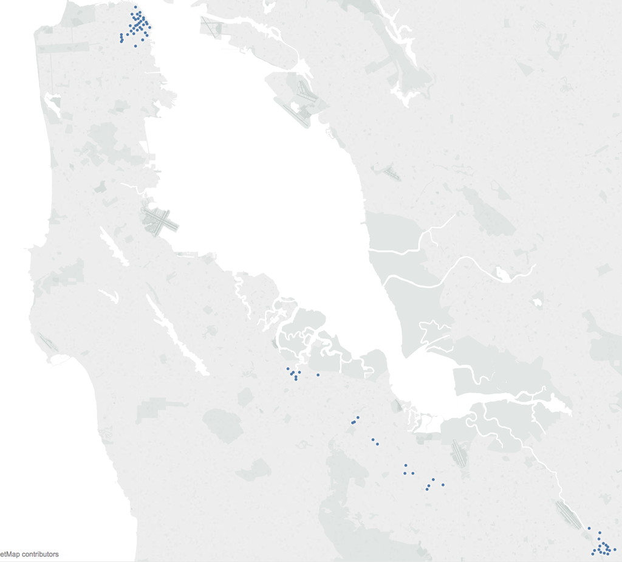

```python
Image("./Images/station_map.png")
```

For the purposes of the project, only the stations in San Francisco will be considered. I chose to do this because this project is meant to predict commute times in San Francisco.

```python
# Select only SF bike stations

sf_stats = [39,41,42,45,46,47,48,49,50,51,54,55,56,57,58,59,60,61,62,63,64,65,66,67,68,69,70,71,72,73,74,75,76,77,82]
msk = (all_data.start_station_id.isin(sf_stats)) & (all_data.end_station_id.isin(sf_stats))
```

```python
all_data = all_data[msk]
```

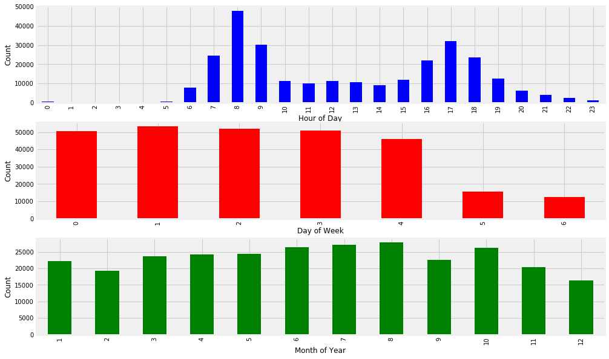

```python
# Plot average trip duration as a function of day of week, hour of day
fig = plt.figure(figsize = (15,10))

plt.subplot(3,1,1)
all_data.groupby(all_data['start_hour'].dt.hour)['duration'].count().plot(kind= 'bar',color = 'blue')
plt.xlabel('Hour of Day')
plt.ylabel('Count')
plt.subplot(3,1,2)
all_data.groupby(all_data['start_hour'].dt.weekday)['duration'].count().plot(kind='bar',color = 'red')
plt.xlabel('Day of Week')
plt.ylabel('Count')
plt.subplot(3,1,3)
all_data.groupby(all_data['start_hour'].dt.month)['duration'].count().plot(kind = 'bar',color = 'green')
plt.xlabel('Month of Year')
plt.ylabel('Count')
```

```python
fig.savefig('./Images/trip_count.jpg')
```

These plots are telling for a few reasons. It appears clear that these bikes are mostly used for work commuting, as their use peaks during typical travel hours (early morning and early evening) and weekdays.

```python
all_data = all_data[all_data.start_hour.dt.weekday.isin(range(5))]
```

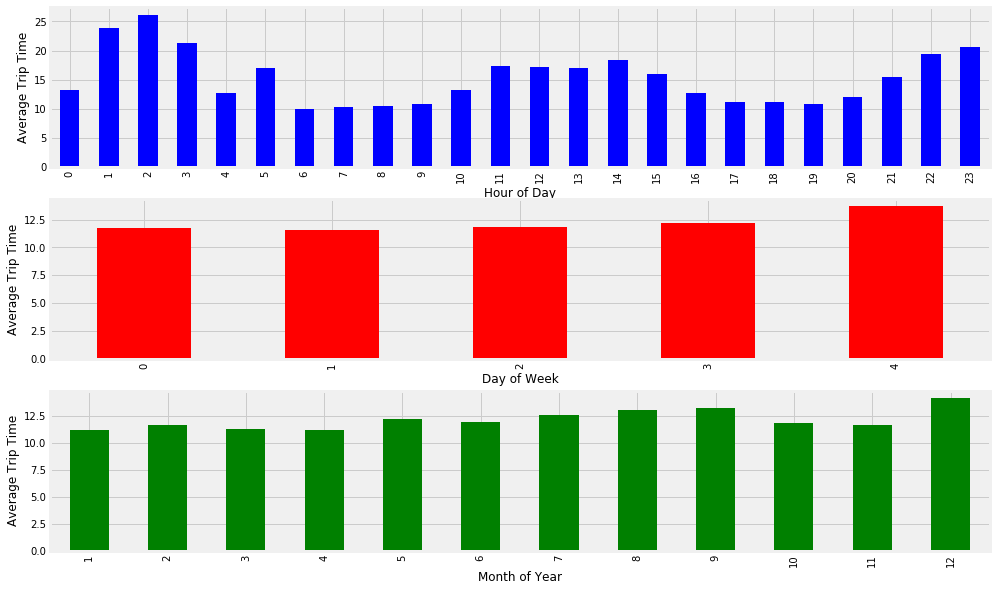

```python
fig2 = plt.figure(figsize = (15,10))
plt.subplot(3,1,1)
all_data.groupby(all_data['start_hour'].dt.hour)['duration'].mean().plot(kind= 'bar',color = 'blue')
plt.xlabel('Hour of Day')
plt.ylabel('Average Trip Time')
plt.subplot(3,1,2)
all_data.groupby(all_data['start_hour'].dt.weekday)['duration'].mean().plot(kind='bar',color = 'red')
plt.xlabel('Day of Week')
plt.ylabel('Average Trip Time')
plt.subplot(3,1,3)
all_data.groupby(all_data['start_hour'].dt.month)['duration'].mean().plot(kind = 'bar',color = 'green')
plt.xlabel('Month of Year')
plt.ylabel('Average Trip Time')
```

```python
fig2.savefig('./Images/avg_trips.jpg')
```

Interestingly, the average commute time appears inversely related to the count. The highest usage hours have the lowest average times. This could possibly be due to people biking more directly on their work commutes and taking longer when they bike for leisure or other non-commute related reasons.

We can also look at the split between customers and subscribers. Customers pay for each ride they take, while subscribes pay a recurring charge to ride as much as they'd like.

```python
all_data.subscription_type.value_counts()
```

```
Subscriber    231610
Customer       20976
Name: subscription_type, dtype: int64
```

Unfortunately, we are not given data on individual users to determine their ride frequency. In lieu of that I am selecting only subscribers for analysis. The rationale for this is that people who have daily commutes will be subscribers because it is more cost effective.

```python
all_data = all_data[all_data['subscription_type'] =='Subscriber']
```

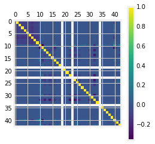

```python
# TODO Select only numerical variables for correlation plot
all_data['hour'] = all_data.start_hour.dt.hour
all_data['weekday'] = all_data.start_hour.dt.weekday
all_data['month'] = all_data.start_hour.dt.month

start_stns_enc = pd.merge(pd.get_dummies(all_data['start_station_id']),pd.DataFrame(all_data.drop(['start_station_id','end_station_id','duration'],axis=1)),right_index =True,left_index=True)

plt.matshow(start_stns_enc.corr())
plt.colorbar()
```

```python
start_stns_enc.corr()
```

|  | 50 | 55 | 60 | 61 | 65 | 67 | 69 | 70 | 74 | 77 | ... | description_smoke | description_squalls | description_thunderstorm | description_thunderstorm with heavy rain | description_thunderstorm with light rain | description_thunderstorm with rain | description_very heavy rain | hour | weekday | month |
| --- | --- | --- | --- | --- | --- | --- | --- | --- | --- | --- | --- | --- | --- | --- | --- | --- | --- | --- | --- | --- | --- |
| 50 | 1.000000 | -0.108864 | -0.083961 | -0.099180 | -0.098775 | -0.086829 | -0.123254 | -0.154029 | -0.099055 | -0.097889 | ... | 0.001167 | NaN | -0.004471 | -0.002785 | -0.000305 | -0.000467 | -0.002631 | -0.097624 | 0.006025 | -0.007409 |
| 55 | -0.108864 | 1.000000 | -0.089942 | -0.106245 | -0.105811 | -0.093014 | -0.132033 | -0.165001 | -0.106111 | -0.104862 | ... | 0.000218 | NaN | 0.001058 | 0.000536 | 0.000490 | 0.002451 | -0.000642 | -0.065620 | -0.008817 | 0.000653 |
| 60 | -0.083961 | -0.089942 | 1.000000 | -0.081941 | -0.081607 | -0.071737 | -0.101831 | -0.127257 | -0.081838 | -0.080875 | ... | -0.001733 | NaN | 0.007184 | -0.000437 | 0.003595 | 0.003507 | 0.002597 | 0.078497 | -0.000149 | -0.002010 |
| 61 | -0.099180 | -0.106245 | -0.081941 | 1.000000 | -0.096399 | -0.084741 | -0.120289 | -0.150324 | -0.096672 | -0.095534 | ... | 0.002827 | NaN | 0.000861 | -0.001614 | 0.004866 | 0.001199 | -0.002513 | 0.065416 | 0.000917 | 0.008874 |
| 65 | -0.098775 | -0.105811 | -0.081607 | -0.096399 | 1.000000 | -0.084395 | -0.119798 | -0.149710 | -0.096277 | -0.095144 | ... | -0.000126 | NaN | 0.004588 | 0.000454 | -0.000006 | 0.006716 | -0.001233 | 0.127461 | -0.004372 | -0.007667 |
| 67 | -0.086829 | -0.093014 | -0.071737 | -0.084741 | -0.084395 | 1.000000 | -0.105310 | -0.131605 | -0.084634 | -0.083638 | ... | -0.003568 | NaN | 0.002536 | -0.000672 | -0.001398 | -0.004575 | 0.002322 | 0.060093 | 0.009129 | 0.003351 |
| 69 | -0.123254 | -0.132033 | -0.101831 | -0.120289 | -0.119798 | -0.105310 | 1.000000 | -0.186812 | -0.120137 | -0.118723 | ... | 0.010333 | NaN | -0.001239 | 0.000204 | -0.002351 | 0.002246 | 0.001672 | -0.048036 | -0.009492 | 0.004190 |
| 70 | -0.154029 | -0.165001 | -0.127257 | -0.150324 | -0.149710 | -0.131605 | -0.186812 | 1.000000 | -0.150134 | -0.148368 | ... | -0.004426 | NaN | -0.003675 | 0.000116 | -0.001270 | -0.004412 | -0.001306 | -0.135188 | 0.006012 | 0.000343 |
| 74 | -0.099055 | -0.106111 | -0.081838 | -0.096672 | -0.096277 | -0.084634 | -0.120137 | -0.150134 | 1.000000 | -0.095414 | ... | 0.000876 | NaN | -0.001324 | 0.000429 | -0.003316 | -0.002870 | -0.003765 | -0.001933 | -0.005616 | -0.001633 |
| 77 | -0.097889 | -0.104862 | -0.080875 | -0.095534 | -0.095144 | -0.083638 | -0.118723 | -0.148368 | -0.095414 | 1.000000 | ... | -0.006518 | NaN | -0.002679 | 0.003614 | 0.000916 | -0.002748 | 0.006439 | 0.102703 | 0.007412 | 0.000566 |
| temperature | -0.041765 | -0.025000 | 0.024158 | 0.025310 | 0.034900 | 0.029174 | 0.001705 | -0.028796 | -0.011748 | 0.012024 | ... | 0.066815 | NaN | 0.060492 | 0.038391 | 0.035077 | 0.045670 | -0.010312 | 0.378858 | 0.016791 | 0.206117 |
| humidity | 0.024633 | 0.011694 | -0.021654 | -0.016119 | -0.020116 | -0.007430 | 0.026681 | 0.009627 | 0.013772 | -0.035194 | ... | -0.037417 | NaN | -0.013904 | -0.035971 | -0.015107 | -0.028408 | -0.004797 | -0.290124 | -0.018717 | -0.009573 |
| description_broken clouds | -0.003592 | -0.000100 | 0.006540 | 0.005223 | 0.005360 | 0.001187 | 0.000723 | -0.012624 | -0.000232 | 0.003310 | ... | -0.021217 | NaN | -0.006410 | -0.004622 | -0.005733 | -0.006904 | -0.003737 | 0.025654 | 0.016703 | -0.066750 |
| description_drizzle | 0.000704 | -0.004143 | -0.000920 | 0.002827 | 0.001735 | -0.000681 | 0.000583 | -0.000958 | -0.000051 | 0.001296 | ... | -0.001809 | NaN | -0.000546 | -0.000394 | -0.000489 | -0.000589 | -0.000319 | 0.003539 | 0.009631 | 0.019219 |
| description_few clouds | 0.000345 | -0.002209 | -0.003935 | -0.000153 | -0.001889 | 0.002678 | 0.000978 | 0.001237 | 0.001432 | 0.000798 | ... | -0.023643 | NaN | -0.007143 | -0.005150 | -0.006388 | -0.007693 | -0.004164 | -0.001386 | -0.015113 | -0.102895 |
| description_fog | 0.011310 | 0.002581 | -0.001534 | -0.005489 | -0.004656 | -0.005558 | 0.000796 | 0.000701 | -0.001549 | 0.001763 | ... | -0.006829 | NaN | -0.002063 | -0.001488 | -0.001845 | -0.002222 | -0.001203 | -0.029874 | -0.000165 | 0.012952 |
| description_haze | -0.007826 | -0.004705 | 0.012069 | 0.007605 | 0.006380 | 0.002495 | -0.007944 | -0.008157 | -0.000784 | 0.007937 | ... | -0.011251 | NaN | -0.003399 | -0.002451 | -0.003040 | -0.003661 | -0.001982 | 0.107353 | -0.002126 | 0.050963 |
| description_heavy intensity drizzle | -0.002295 | -0.002458 | -0.001896 | 0.001990 | 0.002013 | 0.000405 | 0.000784 | -0.000415 | -0.000120 | 0.002065 | ... | -0.000495 | NaN | -0.000150 | -0.000108 | -0.000134 | -0.000161 | -0.000087 | 0.001065 | 0.003793 | -0.008100 |
| description_heavy intensity rain | -0.001488 | 0.000459 | -0.000165 | -0.001324 | 0.011396 | -0.000229 | -0.000156 | 0.002847 | -0.003731 | -0.008775 | ... | -0.005567 | NaN | -0.001682 | -0.001213 | -0.001504 | -0.001812 | -0.000981 | 0.034840 | -0.005255 | 0.089263 |
| description_heavy snow | NaN | NaN | NaN | NaN | NaN | NaN | NaN | NaN | NaN | NaN | ... | NaN | NaN | NaN | NaN | NaN | NaN | NaN | NaN | NaN | NaN |
| description_light intensity drizzle | 0.003163 | -0.000758 | 0.004591 | 0.004763 | -0.002202 | 0.002720 | -0.004151 | -0.008773 | -0.000482 | 0.006191 | ... | -0.001792 | NaN | -0.000541 | -0.000390 | -0.000484 | -0.000583 | -0.000316 | 0.010178 | 0.014362 | 0.015006 |
| description_light intensity shower rain | -0.003006 | -0.001365 | 0.004315 | 0.000515 | 0.001876 | 0.000894 | 0.000814 | -0.004726 | 0.001183 | 0.002009 | ... | -0.001611 | NaN | -0.000487 | -0.000351 | -0.000435 | -0.000524 | -0.000284 | 0.025782 | -0.032673 | 0.011722 |
| description_light rain | -0.008443 | -0.002773 | 0.004119 | 0.004512 | 0.010843 | 0.003898 | -0.002088 | -0.013805 | 0.000757 | 0.010117 | ... | -0.022347 | NaN | -0.006751 | -0.004868 | -0.006038 | -0.007271 | -0.003936 | 0.068323 | -0.003018 | -0.039220 |
| description_light snow | NaN | NaN | NaN | NaN | NaN | NaN | NaN | NaN | NaN | NaN | ... | NaN | NaN | NaN | NaN | NaN | NaN | NaN | NaN | NaN | NaN |
| description_mist | 0.008238 | 0.009635 | -0.001463 | -0.001344 | -0.011782 | -0.012828 | -0.005115 | 0.004706 | 0.005444 | 0.001172 | ... | -0.023882 | NaN | -0.007215 | -0.005202 | -0.006453 | -0.007771 | -0.004206 | -0.081652 | 0.028855 | 0.067481 |
| description_moderate rain | -0.004331 | -0.000652 | -0.003817 | -0.002695 | 0.004712 | 0.002167 | 0.001098 | 0.005655 | -0.004847 | 0.000231 | ... | -0.009507 | NaN | -0.002872 | -0.002071 | -0.002569 | -0.003093 | -0.001674 | 0.025766 | 0.063358 | 0.106649 |
| description_overcast clouds | 0.001629 | 0.001264 | 0.000579 | 0.000594 | 0.001376 | -0.001626 | -0.002241 | 0.000469 | 0.000094 | -0.002147 | ... | -0.013571 | NaN | -0.004100 | -0.002956 | -0.003667 | -0.004416 | -0.002390 | -0.000660 | -0.008249 | -0.053141 |
| description_proximity shower rain | -0.000331 | -0.004512 | 0.002479 | -0.001076 | 0.001853 | 0.001070 | 0.004427 | -0.004164 | 0.001823 | 0.000002 | ... | -0.001089 | NaN | -0.000329 | -0.000237 | -0.000294 | -0.000354 | -0.000192 | 0.024256 | 0.000539 | 0.004510 |
| description_proximity thunderstorm | -0.003982 | -0.000401 | 0.001023 | 0.003800 | 0.004381 | 0.001039 | -0.000201 | -0.006617 | -0.001132 | 0.005071 | ... | -0.002116 | NaN | -0.000639 | -0.000461 | -0.000572 | -0.000689 | -0.000373 | 0.032861 | -0.010111 | 0.003792 |
| description_proximity thunderstorm with rain | 0.000936 | -0.001901 | -0.001812 | -0.000110 | -0.000082 | 0.000807 | -0.000576 | -0.000560 | 0.001138 | 0.002484 | ... | -0.000846 | NaN | -0.000256 | -0.000184 | -0.000229 | -0.000275 | -0.000149 | 0.019328 | -0.003732 | -0.001342 |
| description_scattered clouds | -0.003422 | -0.002759 | -0.001407 | 0.000453 | 0.000493 | 0.001439 | 0.007310 | 0.001938 | 0.000797 | -0.006757 | ... | -0.023396 | NaN | -0.007068 | -0.005096 | -0.006322 | -0.007613 | -0.004121 | -0.000585 | 0.011575 | 0.005672 |
| description_shower rain | 0.000696 | -0.000901 | 0.002401 | 0.003048 | -0.000125 | 0.002097 | -0.003706 | -0.000693 | -0.001218 | -0.000054 | ... | -0.000980 | NaN | -0.000296 | -0.000213 | -0.000265 | -0.000319 | -0.000173 | 0.017282 | -0.019873 | 0.002787 |
| description_sky is clear | 0.005334 | -0.000242 | -0.005687 | -0.007014 | -0.007017 | 0.003177 | 0.000603 | 0.013306 | -0.002420 | -0.005812 | ... | -0.055294 | NaN | -0.016704 | -0.012044 | -0.014940 | -0.017992 | -0.009739 | -0.051967 | -0.030309 | 0.029410 |
| description_smoke | 0.001167 | 0.000218 | -0.001733 | 0.002827 | -0.000126 | -0.003568 | 0.010333 | -0.004426 | 0.000876 | -0.006518 | ... | 1.000000 | NaN | -0.001430 | -0.001031 | -0.001279 | -0.001540 | -0.000834 | -0.013036 | -0.021433 | 0.034428 |
| description_squalls | NaN | NaN | NaN | NaN | NaN | NaN | NaN | NaN | NaN | NaN | ... | NaN | NaN | NaN | NaN | NaN | NaN | NaN | NaN | NaN | NaN |
| description_thunderstorm | -0.004471 | 0.001058 | 0.007184 | 0.000861 | 0.004588 | 0.002536 | -0.001239 | -0.003675 | -0.001324 | -0.002679 | ... | -0.001430 | NaN | 1.000000 | -0.000311 | -0.000386 | -0.000465 | -0.000252 | 0.019987 | -0.018955 | 0.006093 |
| description_thunderstorm with heavy rain | -0.002785 | 0.000536 | -0.000437 | -0.001614 | 0.000454 | -0.000672 | 0.000204 | 0.000116 | 0.000429 | 0.003614 | ... | -0.001031 | NaN | -0.000311 | 1.000000 | -0.000279 | -0.000335 | -0.000182 | 0.016398 | 0.012328 | -0.004447 |
| description_thunderstorm with light rain | -0.000305 | 0.000490 | 0.003595 | 0.004866 | -0.000006 | -0.001398 | -0.002351 | -0.001270 | -0.003316 | 0.000916 | ... | -0.001279 | NaN | -0.000386 | -0.000279 | 1.000000 | -0.000416 | -0.000225 | 0.013441 | -0.013872 | 0.005903 |
| description_thunderstorm with rain | -0.000467 | 0.002451 | 0.003507 | 0.001199 | 0.006716 | -0.004575 | 0.002246 | -0.004412 | -0.002870 | -0.002748 | ... | -0.001540 | NaN | -0.000465 | -0.000335 | -0.000416 | 1.000000 | -0.000271 | 0.026456 | -0.019682 | 0.011438 |
| description_very heavy rain | -0.002631 | -0.000642 | 0.002597 | -0.002513 | -0.001233 | 0.002322 | 0.001672 | -0.001306 | -0.003765 | 0.006439 | ... | -0.000834 | NaN | -0.000252 | -0.000182 | -0.000225 | -0.000271 | 1.000000 | 0.015534 | 0.002361 | -0.007624 |
| hour | -0.097624 | -0.065620 | 0.078497 | 0.065416 | 0.127461 | 0.060093 | -0.048036 | -0.135188 | -0.001933 | 0.102703 | ... | -0.013036 | NaN | 0.019987 | 0.016398 | 0.013441 | 0.026456 | 0.015534 | 1.000000 | -0.012050 | 0.000265 |
| weekday | 0.006025 | -0.008817 | -0.000149 | 0.000917 | -0.004372 | 0.009129 | -0.009492 | 0.006012 | -0.005616 | 0.007412 | ... | -0.021433 | NaN | -0.018955 | 0.012328 | -0.013872 | -0.019682 | 0.002361 | -0.012050 | 1.000000 | -0.025891 |
| month | -0.007409 | 0.000653 | -0.002010 | 0.008874 | -0.007667 | 0.003351 | 0.004190 | 0.000343 | -0.001633 | 0.000566 | ... | 0.034428 | NaN | 0.006093 | -0.004447 | 0.005903 | 0.011438 | -0.007624 | 0.000265 | -0.025891 | 1.000000 |

43 rows × 43 columns

For the correlation plot the start stations were one-hot encoded. The correlation matrix shows very little interaction between most of the features, which is good for future modeling. Some features do show some unsurprising correlation, for instance temperature with hour of day and month and humidity with hour of day.

```python
rtes = all_data[['start_station_id','end_station_id']].apply(lambda x: str(x[0])+'->'+str(x[1]),axis =1)
rtes.value_counts()[:20]
```

```
69->65    5709
65->70    4576
61->50    4118
50->61    3727
60->74    3674
74->61    3628
55->70    3431
70->55    3400
77->64    3213
74->70    3210
69->39    3190
65->69    3160
50->60    3146
67->70    3019
70->50    3012
70->51    2943
61->74    2704
70->74    2684
69->57    2653
50->70    2574
dtype: int64
```

Moving forward from EDA:

#### 4. Feature Engineering

For feature engineering I'm going to normalize the weather variables using the `scale` method in `sklearn`. For Timestamp data I'll extract hour, day of week, and month of year to serve as their own features. Normalizing the weather data will improve the models predictive ability by removing the effect large outliers might have. By pulling out individual time features it will allow me how different time scales affect trip time.

Since the weather data is taken at hourly intervals I'll have to bucketize the bikeshare data into matching intervals. I may also only select for trips along the most popular routes as a way to pare down the data into a more manageable sample. This will help boost performance time of the model while still retaining the most pertinent information.

Trip durations are given to the second, however in planning a commute that type of precision isn't necessary so I plan to round trip durations to the nearest minute. This should improve the models performance as well since it will not be required to predict super precisely.

```python
# Create feature and response vectors
X = all_data.drop(['duration','subscription_type','start_hour'],axis = 1)
y = all_data.duration

# Scale weather features

X['temperature'] = scale(X.temperature)
X['humidity'] = scale(X.humidity)
```

```python
X.head()
```

|  | start_station_id | end_station_id | temperature | humidity | description_broken clouds | description_drizzle | description_few clouds | description_fog | description_haze | description_heavy intensity drizzle | ... | description_smoke | description_squalls | description_thunderstorm | description_thunderstorm with heavy rain | description_thunderstorm with light rain | description_thunderstorm with rain | description_very heavy rain | hour | weekday | month |
| --- | --- | --- | --- | --- | --- | --- | --- | --- | --- | --- | --- | --- | --- | --- | --- | --- | --- | --- | --- | --- | --- |
| 0 | 74 | 50 | 3.232346 | -0.373574 | 0 | 0 | 0 | 0 | 0 | 0 | ... | 0 | 0 | 0 | 0 | 0 | 0 | 0 | 22 | 3 | 8 |
| 1 | 74 | 49 | 3.232346 | -0.373574 | 0 | 0 | 0 | 0 | 0 | 0 | ... | 0 | 0 | 0 | 0 | 0 | 0 | 0 | 22 | 3 | 8 |
| 2 | 77 | 74 | 3.232346 | -0.373574 | 0 | 0 | 0 | 0 | 0 | 0 | ... | 0 | 0 | 0 | 0 | 0 | 0 | 0 | 22 | 3 | 8 |
| 4 | 55 | 51 | 0.081697 | 0.661747 | 1 | 0 | 0 | 0 | 0 | 0 | ... | 0 | 0 | 0 | 0 | 0 | 0 | 0 | 13 | 3 | 8 |
| 5 | 67 | 72 | 0.081697 | 0.661747 | 1 | 0 | 0 | 0 | 0 | 0 | ... | 0 | 0 | 0 | 0 | 0 | 0 | 0 | 13 | 3 | 8 |

5 rows × 35 columns

#### 5. Model Selection

To measure the error of the model I used mean absolute percent error (MAPE). This is a good metric for this particular problem because it gives a concrete scale for how far off a commute prediction is on average. For instance a 10 minute commute with a 25% MAPE means that the model predicts a commute between 7.5 and 12.5 minutes typically.

```python
# code adapted from: https://gist.github.com/amanahuja/6315882
def mean_absolute_percentage_error(y_true, y_pred):
    y_true, y_pred = np.array(y_true), np.array(y_pred)
    return np.mean(np.abs((y_true - y_pred) / y_true)) * 100
```

```python
X_train,X_test,y_train,y_test = train_test_split(X,y,test_size =0.25)
n = range(5,101,5)
scores = []
```

Random forests are nice because they are so flexible and have lots of parameters to tune, the two I chose to tweak for this problem were the number of estimators and minimum samples on a leaf.

```python
# find score for different leaf sizes
for i in n:
    print(i)
    rf = RandomForestRegressor(n_estimators = i)
    rf.fit(X_train,y_train)
    y_pred = rf.predict(X_test)
    scores.append(mean_absolute_percentage_error(y_test,y_pred))
```

```
5
10
15
20
25
30
35
40
45
50
55
60
65
70
75
80
85
90
95
100
```

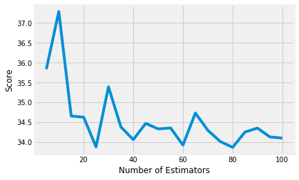

```python
fig3 = plt.figure()
plt.plot(n,scores)
plt.xlabel('Number of Estimators')
plt.ylabel('Score')
```

```python
fig3.savefig('./Images/n_estimators.jpg')
```

```python
# find score for different min leaf sizes
mins = range(5,51,5)
scores_leaf = []
for n in mins:
    rf = RandomForestRegressor(min_samples_leaf=n)
    rf.fit(X_train,y_train)
    y_pred = rf.predict(X_test)
    scores_leaf.append(mean_absolute_percentage_error(y_test,y_pred))
```

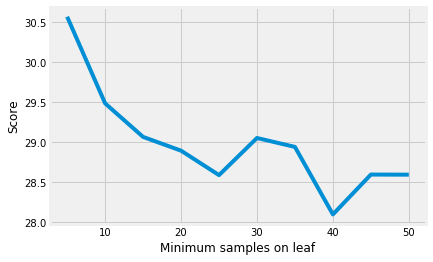

```python
fig4 = plt.figure()
plt.plot(mins,scores_leaf)
plt.xlabel('Minimum samples on leaf')
plt.ylabel('Score')
```

```python
fig4.savefig('./Images/samples_on_leaf.jpg')
```

```python
# build model with tuned parameters
rff = RandomForestRegressor(n_estimators = 100, min_samples_leaf=15)
rff.fit(X_train,y_train)
y_predf = rff.predict(X_test)

mean_absolute_percentage_error(y_test,y_predf)
```

```
27.890773869191715
```

```python
rff.feature_importances_
```

```
array([  5.97746643e-02,   3.19433240e-01,   2.14096376e-01,
         1.37100630e-01,   5.63777893e-03,   0.00000000e+00,
         5.16639863e-03,   1.43666257e-03,   6.42939206e-03,
         0.00000000e+00,   1.09002258e-02,   0.00000000e+00,
         0.00000000e+00,   0.00000000e+00,   9.06865665e-03,
         0.00000000e+00,   3.20988136e-03,   1.18721645e-02,
         7.93969181e-04,   0.00000000e+00,   0.00000000e+00,
         0.00000000e+00,   7.64106655e-03,   0.00000000e+00,
         1.76497741e-02,   3.41300280e-05,   0.00000000e+00,
         0.00000000e+00,   0.00000000e+00,   0.00000000e+00,
         0.00000000e+00,   0.00000000e+00,   7.16193864e-02,
         6.24420163e-02,   5.56935860e-02])
```

```python
ft_impts = pd.DataFrame({'features':X.columns,'importance':rff.feature_importances_})
```

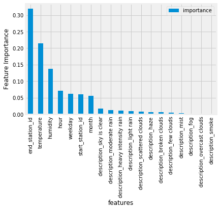

```python
# plot the most important features
ft_impts = ft_impts[ft_impts['importance'] >0].sort_values(by='importance',ascending = False)
ft_impts.set_index('features').plot(kind='bar')
plt.ylabel('Feature Importance')
```

After tuning the parameters I was able to improve the performance from ~35% to ~27%. This error is slightly higher than I was aiming for but considering we're predicting commute times, it doesn't need to be right on. What this does show though, is that weather does play a role in commute times and that using past data we can use that data to predict future commutes. This could be useful in applications like Google Maps, which could use weather forecasts to improve their commute estimates.